# INTRODUCCIÓN A R. ESTADÍSTICA DESCRIPTIVA Y MODELOS LINEALES.

### EJERCICIO EVALUABLE M06-DC02: INTRODUCCIÓN A R.

##### CARLOS ALFONSEL carlos.alfonsel@mbitschool.com

2020-04-08

**EJERCICIO EVALUABLE 2019-2020. INTRODUCCIÓN A R, ESTADÍSTICA Y MODELOS LINEALES.**

**MBIT BIG DATA, CLOUD & ANALYTICS MARZO 2020**

Carlos Alfonsel carlos.alfonsel@mbitschool.com

# 1 Instalación y Uso de Librerías. Carga de Ficheros.

## 1.1 Instala o carga los paquetes MASS e ISLR en tu distribución de R.

```r
library(MASS)
library(ISLR)
```

## 1.2 Carga el fichero DataPLanes_OK.csv contenido en la carpeta data en la variable de R de tipo dataframe DataPlanes_OK. ¿Cuál es el número de filas y columnas del dataframe?.

```r
# Se importa el fichero CSV, teniendo en cuenta que la primera fila incluye los nombres de las variables, que el separador entre campos es el carácter ";", y que la primera columna indica el número de fila:
DataPlanes_OK <- read.csv("./data/DataPLanes_OK.csv", header = TRUE, sep = ";", row.names = 1)

# Se comprueba que el elemento creado es de tipo "dataframe":
class(DataPlanes_OK)
```

```
## [1] "data.frame"
```

```r
# Se sacan por consola las 10 primeras filas del dataframe:
head(DataPlanes_OK, 10)
```

```
##    year month day dep_time sched_dep_time dep_delay arr_time sched_arr_time
## 1  2013     1   1      517            515         2      830            819
## 2    NA     1   1      533            529         4      850            830
## 3  2013     1   1      542            540         2      923            850
## 4  2013     1   1      544            545        -1     1004           1022
## 5  2013     1   1      554            600        -6      812            837
## 6  2013     1   1      554            558        -4      740            728
## 7  2013     1   1      555            600        -5      913            854
## 8  2013     1   1      557            600        -3      709            723
## 9  2013     1   1      557            600        -3      838            846
## 10 2013     1   1      558            600        -2      753            745
##    arr_delay carrier flight tailnum origin dest air_time distance hour minute
## 1         NA      UA   1545  N14228    EWR  IAH      227     1400    5     15
## 2         20      UA   1714  N24211    LGA  IAH      227     1416    5     29
## 3         33      AA   1141  N619AA    JFK  MIA      160     1089    5     40
```

[output cut: 18 more lines]

**Número de filas y columnas del dataframe creado (DataPlanes_OK):**

```r
# Número de filas del dataframe
paste("NÚMERO DE FILAS = ", nrow(DataPlanes_OK))
```

```
## [1] "NÚMERO DE FILAS =  336776"
```

```r
# Número de columnas del dataframe
paste("NÚMERO COLUMNAS = ", ncol(DataPlanes_OK))
```

```
## [1] "NÚMERO COLUMNAS =  19"
```

# 2 Muestreo y Manejo de Valores Ausentes.

## 2.1 Selecciona una muestra aleatoria sin reemplazo del 20% de las filas del dataframe DataPlanes_OK_filter. Pista: busca ayuda sobre la función sample.

```r
# Creamos el nuevo dataframe a partir de un muestreo aleatorio sin reemplazo del 20% de las filas del dataframe original:
DataPlanes_OK_filter <- DataPlanes_OK[sample(0.2*nrow(DataPlanes_OK), replace = F),]

# Vemos las 10 primeras filas del nuevo dataframe DataPlanes_OK_filter:
head(DataPlanes_OK_filter, 10)
```

```
##       year month day dep_time sched_dep_time dep_delay arr_time sched_arr_time
## 66422 2013    11  12     1345           1351        -6     1700           1702
## 26592 2013     1  31     1602           1600         2     1919           1915
## 20807 2013     1  24     1947           1945         2     2251           2241
## 4198  2013     1   5     1816           1812         4     2119           2137
## 14247 2013     1  17      914            920        -6     1131           1125
## 7347  2013     1   9     1140           1127        13     1424           1353
## 32608 2013    10   7      639            637         2     1019            923
## 35380 2013    10   9     2011           2011         0     2134           2149
## 64461 2013    11  10     1320           1329        -9     1427           1440
## 5047  2013     1   6     1924           1925        -1     2243           2247
##       arr_delay carrier flight tailnum origin dest air_time distance hour
## 66422        -2      DL   1775  N351NW    LGA  MIA      157     1096   13
## 26592         4      AA    565  N3FWAA    JFK  DFW      226     1391   16
## 20807        10      9E   3314  N604LR    JFK  JAX      116      828   19
```

[output cut: 18 more lines]

```r
# Comprobamos que el número de filas del nuevo dataframe es el 20% del original:
paste("NÚMERO DE FILAS DATAFRAME MUESTREADO = ", nrow(DataPlanes_OK_filter))
```

```
## [1] "NÚMERO DE FILAS DATAFRAME MUESTREADO =  67355"
```

```r
paste("NÚMERO COLUMNAS DATAFRAME MUESTREADO = ", ncol(DataPlanes_OK_filter))
```

```
## [1] "NÚMERO COLUMNAS DATAFRAME MUESTREADO =  19"
```

## 2.2 En el data frame DataPlanes_OK_filter, elimina las filas que contengan algún NA y almacena el nuevo dataframe en una variable de R llamada DataPlanes_OK_filter_clean.

```r
# Hacemos un summary del dataframe DataPlanes_OK_filter para comprobar si hay valores ausentes:
summary(DataPlanes_OK_filter)
```

```
##       year          month             day           dep_time    sched_dep_time
##  Min.   :2013   Min.   : 1.000   Min.   : 1.00   Min.   :   1   Min.   : 500
##  1st Qu.:2013   1st Qu.: 1.000   1st Qu.: 7.00   1st Qu.: 904   1st Qu.: 900
##  Median :2013   Median :10.000   Median :13.00   Median :1354   Median :1355
##  Mean   :2013   Mean   : 6.562   Mean   :14.42   Mean   :1341   Mean   :1336
##  3rd Qu.:2013   3rd Qu.:10.000   3rd Qu.:22.00   3rd Qu.:1733   3rd Qu.:1724
##  Max.   :2013   Max.   :11.000   Max.   :31.00   Max.   :2400   Max.   :2359
##  NA's   :2                                       NA's   :867    NA's   :1
##    dep_delay           arr_time    sched_arr_time   arr_delay
##  Min.   : -32.000   Min.   :   1   Min.   :   1   Min.   : -70.000
##  1st Qu.:  -6.000   1st Qu.:1115   1st Qu.:1127   1st Qu.: -16.000
##  Median :  -2.000   Median :1546   Median :1556   Median :  -5.000
##  Mean   :   7.446   Mean   :1520   Mean   :1541   Mean   :   2.472
##  3rd Qu.:   5.000   3rd Qu.:1941   3rd Qu.:1944   3rd Qu.:   9.000
##  Max.   :1301.000   Max.   :2400   Max.   :2359   Max.   :1272.000
##  NA's   :867        NA's   :906                   NA's   :1018
##     carrier          flight        tailnum      origin           dest
##  UA     :11759   Min.   :   1   N725MQ :  111   EWR:24082   ORD    : 3480
##  EV     :10975   1st Qu.: 525   N0EGMQ :  107   JFK:21893   ATL    : 3426
##  B6     :10514   Median :1503   N542MQ :  104   LGA:21380   BOS    : 3139
##  DL     : 9407   Mean   :1982   N283JB :  100               LAX    : 3136
##  AA     : 6595   3rd Qu.:3493   N528MQ :  100               CLT    : 2858
##  MQ     : 5364   Max.   :8500   (Other):66561               MCO    : 2768
##  (Other):12741   NA's   :1      NA's   :  272               (Other):48548
##     air_time       distance         hour          minute
##  Min.   : 20    Min.   :  80   Min.   : 5.0   Min.   : 0.00
##  1st Qu.: 83    1st Qu.: 502   1st Qu.: 9.0   1st Qu.: 6.00
##  Median :131    Median : 828   Median :13.0   Median :29.00
##  Mean   :152    Mean   :1027   Mean   :13.1   Mean   :25.81
##  3rd Qu.:193    3rd Qu.:1389   3rd Qu.:17.0   3rd Qu.:43.00
##  Max.   :676    Max.   :4983   Max.   :23.0   Max.   :59.00
##  NA's   :1017
##    time_hour
##  Min.   :1.357e+09
##  1st Qu.:1.359e+09
##  Median :1.381e+09
##  Mean   :1.373e+09
##  3rd Qu.:1.383e+09
##  Max.   :1.384e+09
##  NA's   :1
```

```r
# Vemos las dimenciones del dataframe mencionado:
dim(DataPlanes_OK_filter)
```

```
## [1] 67355    19
```

**Eliminamos las filas con valores NA y vemos el tamaño del nuevo dataframe:**

```r
# Mediante la función na.omit eliminamos las filas con algún campo con missing value:
DataPlanes_OK_filter_clean <- na.omit(DataPlanes_OK_filter)

# Vemos las 10 primeras filas del dataframe DataPlanes_OK_filter_clean:
head(DataPlanes_OK_filter_clean, 10)
```

```
##       year month day dep_time sched_dep_time dep_delay arr_time sched_arr_time
## 66422 2013    11  12     1345           1351        -6     1700           1702
## 26592 2013     1  31     1602           1600         2     1919           1915
## 20807 2013     1  24     1947           1945         2     2251           2241
## 4198  2013     1   5     1816           1812         4     2119           2137
## 14247 2013     1  17      914            920        -6     1131           1125
## 7347  2013     1   9     1140           1127        13     1424           1353
## 32608 2013    10   7      639            637         2     1019            923
## 35380 2013    10   9     2011           2011         0     2134           2149
## 64461 2013    11  10     1320           1329        -9     1427           1440
## 5047  2013     1   6     1924           1925        -1     2243           2247
##       arr_delay carrier flight tailnum origin dest air_time distance hour
## 66422        -2      DL   1775  N351NW    LGA  MIA      157     1096   13
## 26592         4      AA    565  N3FWAA    JFK  DFW      226     1391   16
## 20807        10      9E   3314  N604LR    JFK  JAX      116      828   19
```

[output cut: 18 more lines]

```r
# Comprobamos que el nuevo dataframe no tiene ningún campo con valor NA:
summary(DataPlanes_OK_filter_clean)
```

```
##       year          month            day           dep_time    sched_dep_time
##  Min.   :2013   Min.   : 1.00   Min.   : 1.00   Min.   :   1   Min.   : 500
##  1st Qu.:2013   1st Qu.: 1.00   1st Qu.: 7.00   1st Qu.: 904   1st Qu.: 900
##  Median :2013   Median :10.00   Median :13.00   Median :1354   Median :1351
##  Mean   :2013   Mean   : 6.59   Mean   :14.37   Mean   :1341   Mean   :1335
##  3rd Qu.:2013   3rd Qu.:10.00   3rd Qu.:22.00   3rd Qu.:1733   3rd Qu.:1723
##  Max.   :2013   Max.   :11.00   Max.   :31.00   Max.   :2400   Max.   :2359
##
##    dep_delay           arr_time    sched_arr_time   arr_delay
##  Min.   : -32.000   Min.   :   1   Min.   :   1   Min.   : -70.000
##  1st Qu.:  -6.000   1st Qu.:1115   1st Qu.:1125   1st Qu.: -16.000
##  Median :  -2.000   Median :1545   Median :1555   Median :  -5.000
##  Mean   :   7.415   Mean   :1520   Mean   :1540   Mean   :   2.471
##  3rd Qu.:   5.000   3rd Qu.:1941   3rd Qu.:1944   3rd Qu.:   9.000
##  Max.   :1301.000   Max.   :2400   Max.   :2359   Max.   :1272.000
##
##     carrier          flight        tailnum      origin           dest
##  UA     :11674   Min.   :   1   N725MQ :  110   EWR:23654   ORD    : 3412
##  EV     :10631   1st Qu.: 523   N0EGMQ :  105   JFK:21679   ATL    : 3386
##  B6     :10485   Median :1491   N542MQ :  104   LGA:20996   LAX    : 3101
##  DL     : 9363   Mean   :1966   N283JB :  100               BOS    : 3080
##  AA     : 6504   3rd Qu.:3475   N528MQ :  100               CLT    : 2813
##  MQ     : 5224   Max.   :8500   N6EAMQ :   93               MCO    : 2765
##  (Other):12448                  (Other):65717               (Other):47772
##     air_time      distance         hour           minute
##  Min.   : 20   Min.   :  80   Min.   : 5.00   Min.   : 0.00
##  1st Qu.: 83   1st Qu.: 502   1st Qu.: 9.00   1st Qu.: 6.00
##  Median :131   Median : 872   Median :13.00   Median :29.00
##  Mean   :152   Mean   :1032   Mean   :13.09   Mean   :25.81
##  3rd Qu.:193   3rd Qu.:1389   3rd Qu.:17.00   3rd Qu.:43.00
##  Max.   :676   Max.   :4983   Max.   :23.00   Max.   :59.00
##
##    time_hour
##  Min.   :1.357e+09
##  1st Qu.:1.359e+09
##  Median :1.381e+09
##  Mean   :1.373e+09
##  3rd Qu.:1.383e+09
##  Max.   :1.384e+09
##
```

```r
dim(DataPlanes_OK_filter_clean)
```

```
## [1] 66329    19
```

```r
paste("FILAS ELIMINADAS = ", nrow(DataPlanes_OK_filter) - nrow(DataPlanes_OK_filter_clean))
```

```
## [1] "FILAS ELIMINADAS =  1026"
```

# 3 Estadísticos Descriptivos.

**Calcula la media, primer cuartil, mediana, tercer cuartil mínimo y máximo de las varibles contenidas en las columnas del dataframe DataPlanes_OK_filter_clean.**

```r
# Con la función summary podemos obtener todos los estadísticos solicitados en el enunciado:
summary(DataPlanes_OK_filter_clean)
```

```
##       year          month            day           dep_time    sched_dep_time
##  Min.   :2013   Min.   : 1.00   Min.   : 1.00   Min.   :   1   Min.   : 500
##  1st Qu.:2013   1st Qu.: 1.00   1st Qu.: 7.00   1st Qu.: 904   1st Qu.: 900
##  Median :2013   Median :10.00   Median :13.00   Median :1354   Median :1351
##  Mean   :2013   Mean   : 6.59   Mean   :14.37   Mean   :1341   Mean   :1335
##  3rd Qu.:2013   3rd Qu.:10.00   3rd Qu.:22.00   3rd Qu.:1733   3rd Qu.:1723
##  Max.   :2013   Max.   :11.00   Max.   :31.00   Max.   :2400   Max.   :2359
##
##    dep_delay           arr_time    sched_arr_time   arr_delay
##  Min.   : -32.000   Min.   :   1   Min.   :   1   Min.   : -70.000
##  1st Qu.:  -6.000   1st Qu.:1115   1st Qu.:1125   1st Qu.: -16.000
##  Median :  -2.000   Median :1545   Median :1555   Median :  -5.000
##  Mean   :   7.415   Mean   :1520   Mean   :1540   Mean   :   2.471
##  3rd Qu.:   5.000   3rd Qu.:1941   3rd Qu.:1944   3rd Qu.:   9.000
##  Max.   :1301.000   Max.   :2400   Max.   :2359   Max.   :1272.000
##
##     carrier          flight        tailnum      origin           dest
##  UA     :11674   Min.   :   1   N725MQ :  110   EWR:23654   ORD    : 3412
##  EV     :10631   1st Qu.: 523   N0EGMQ :  105   JFK:21679   ATL    : 3386
##  B6     :10485   Median :1491   N542MQ :  104   LGA:20996   LAX    : 3101
##  DL     : 9363   Mean   :1966   N283JB :  100               BOS    : 3080
##  AA     : 6504   3rd Qu.:3475   N528MQ :  100               CLT    : 2813
##  MQ     : 5224   Max.   :8500   N6EAMQ :   93               MCO    : 2765
##  (Other):12448                  (Other):65717               (Other):47772
##     air_time      distance         hour           minute
##  Min.   : 20   Min.   :  80   Min.   : 5.00   Min.   : 0.00
##  1st Qu.: 83   1st Qu.: 502   1st Qu.: 9.00   1st Qu.: 6.00
##  Median :131   Median : 872   Median :13.00   Median :29.00
##  Mean   :152   Mean   :1032   Mean   :13.09   Mean   :25.81
##  3rd Qu.:193   3rd Qu.:1389   3rd Qu.:17.00   3rd Qu.:43.00
##  Max.   :676   Max.   :4983   Max.   :23.00   Max.   :59.00
##
##    time_hour
##  Min.   :1.357e+09
##  1st Qu.:1.359e+09
##  Median :1.381e+09
##  Mean   :1.373e+09
##  3rd Qu.:1.383e+09
##  Max.   :1.384e+09
##
```

**NOTA IMPORTANTE**: *cabe señalar que los estadísticos solicitados (media, mediana, primer y tercer cuartil, mínimo y máximo) sólo se pueden calcular para las variables de tipo numérico.*

# 4 Modelos Lineales.

## 4.1 Obtén un modelo lineal (pendiente y ordenada en el origen) que permita obtener la relación entre la variable arr_delay y dep_delay.

```r
# Mediante la función attach añadimos el path del dataframe al sistema:
attach(DataPlanes_OK_filter_clean)

# Mediante la función lm obtenemos una regresión lineal simple entre las variables arr_delay y dep_delay:
lm.fit = lm(arr_delay~dep_delay)

# La función coef nos permite obtener los coeficientes del modelo lineal: pendiente y ordenada en el origen.
coef(lm.fit)
```

```
## (Intercept)   dep_delay
##   -4.951874    1.001191
```

## 4.2 Obtén el error estándar de la pendiente y la ordenada en el origen del ajuste realizado. ¿Cuál es el R2 del ajuste realizado?. ¿Podemos afirmar que la relación es lineal en base al valor de R2?.**

```r
# La función summary nos presenta un resumen de los parámetros más importantes del modelo:
summary(lm.fit)
```

```
##
## Call:
## lm(formula = arr_delay ~ dep_delay)
##
## Residuals:
##     Min      1Q  Median      3Q     Max
## -64.062 -10.041  -1.047   8.947 200.954
##
## Coefficients:
##              Estimate Std. Error t value Pr(>|t|)
## (Intercept) -4.951874   0.062306  -79.48   <2e-16 ***
## dep_delay    1.001191   0.001901  526.70   <2e-16 ***
## ---
## Signif. codes:  0 '***' 0.001 '**' 0.01 '*' 0.05 '.' 0.1 ' ' 1
##
## Residual standard error: 15.63 on 66327 degrees of freedom
## Multiple R-squared:  0.807,  Adjusted R-squared:  0.807
## F-statistic: 2.774e+05 on 1 and 66327 DF,  p-value: < 2.2e-16
```

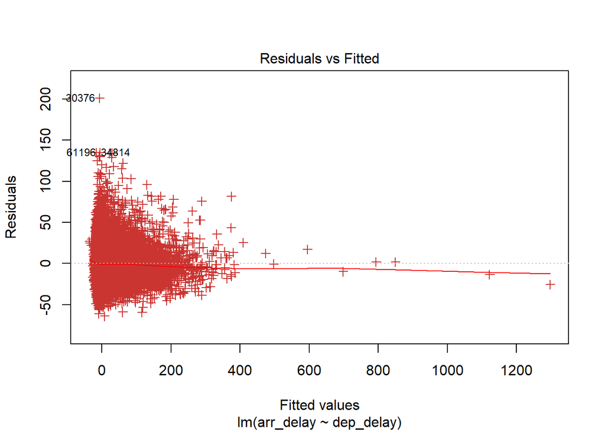

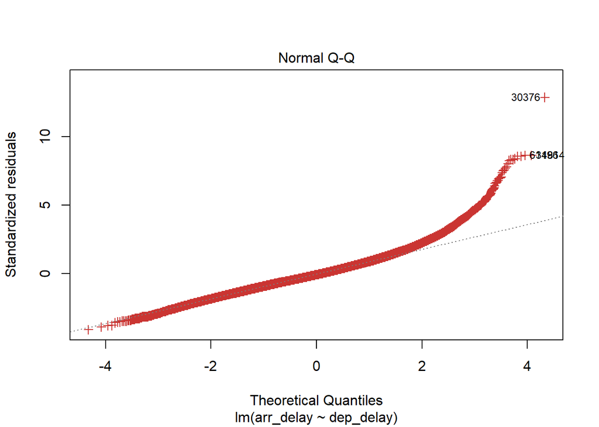

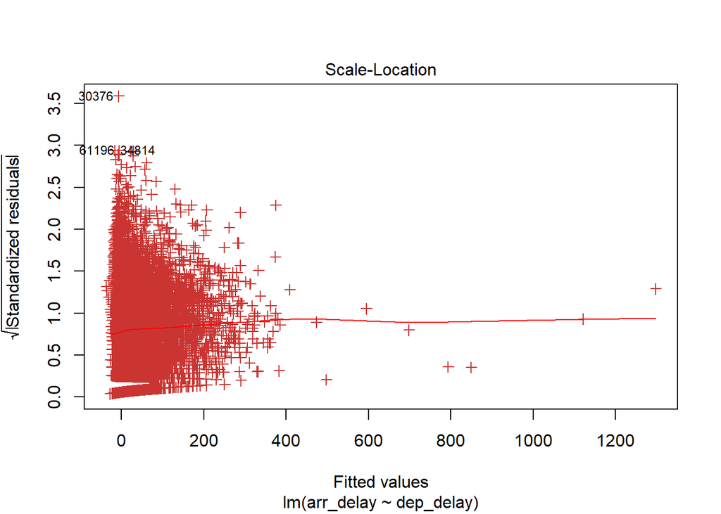

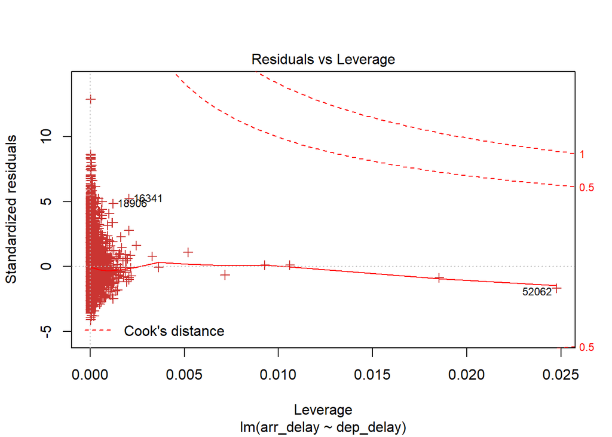

```r
# Mediante la función plot podemos obtener una representación gráfica de algunos aspectos del modelo:
plot(lm.fit, pch = 3, col = "#CA3532")
```

**¿Cuál es el R2 del ajuste realizado?:**

*En base a los resultados obtenidos, el Coeficiente de Determinación (R2) Ajustado es 0.807 (80.7%).*

## 4.3 Representa en un gráfico de dispersión las variables arr_delay en el eje y y dep_delay en el eje x. Representa en el mismo gráfico la recta de regresión obtenida con el modelo. Viendo la relación entre ambas variables, ¿piensas que las conclusiones que has sacado en el partado anterior son correctas?.

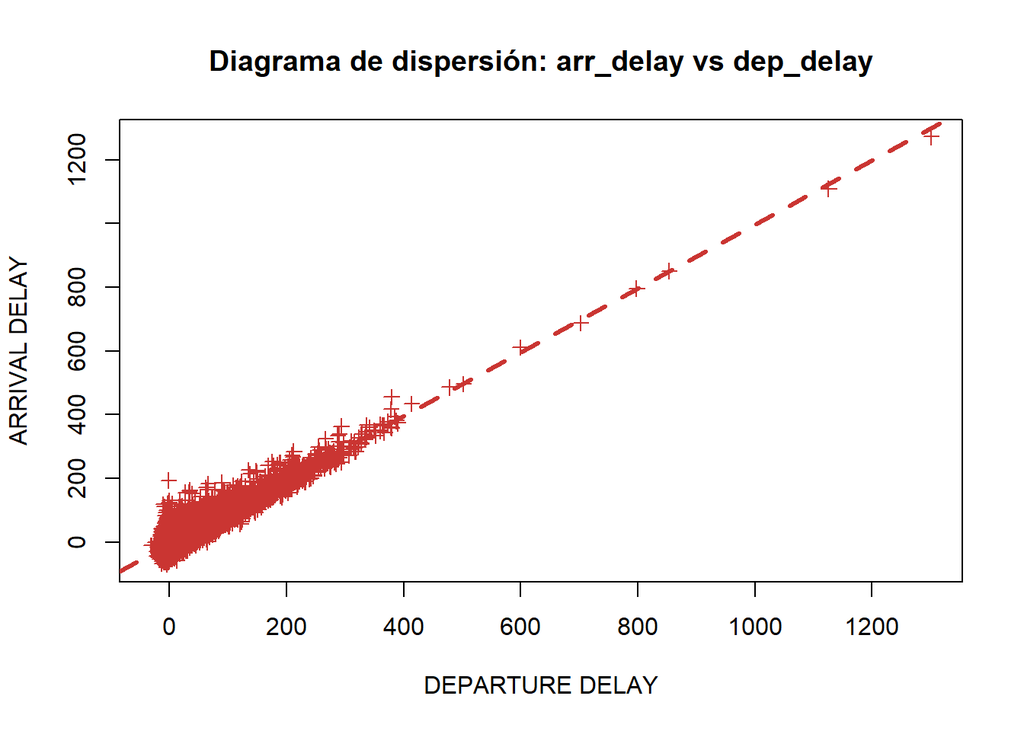

```r
# Con la función plot(x, y, ...) dibujamos un diagrama de dispersión de las variables indicadas, y con las etiquetas pch, col, main, xlab e ylab modificamos las características del gráfico: tipo de punto, color, título del gráfico y de los ejes.
plot(dep_delay,
     arr_delay,
     pch = 3,
     col = "#CA3532",
     main = "Diagrama de dispersión: arr_delay vs dep_delay",
     xlab = "DEPARTURE DELAY",
     ylab = "ARRIVAL DELAY")

# Con la función abline(x, ...) añadimos la recta obtenida en el apartado 4.a como resultado de la aplicación de una regresión lineal: igualmente con las etiquetas lty, lwd y col modificamos las características de tipo, tamaño y color de la línea.
abline(lm.fit,
       lty = 2,
       lwd = 3,
       col = "#CA3532")
```

**Viendo la relación entre ambas variables, ¿piensas que las conclusiones que has sacado en el apartado anterior son correctas?:**

*En base a los resultados gráficos obtenidos, las conclusiones del apartado anterior a partir del valor de R2 (Coef. de Determinación) Ajustado se ven confirmadas, puesto que podemos ver que la relación real entre estas variables se ajusta bastante bien a la regresión lineal calculada.*